# DSTI_TimeSeries

```r
install.packages("readxl")
install.packages("fpp2")
```

```r
library(ggfortify)
library(readr)
library(forecast)
```

```r
'data_raw <- read_excel("data\\raw\\Elec-train.xlsx")
data <- read_excel("data\\processed\\Elec-train-processed-2.xlsx", col_names = TRUE, col_types = c("date", "numeric", "numeric"))
'
```

```
[1] "data_raw <- read_excel(\"data\\raw\\Elec-train.xlsx\")\ndata <- read_excel(\"data\\processed\\Elec-train-processed-2.xlsx\", col_names = TRUE, col_types = c(\"date\", \"numeric\", \"numeric\"))\n"
```

```r
data <- read_csv2("data\\processed\\Elec-train-processed-2.csv", col_names = TRUE, col_types = c("n", "n"))
```

```
i Using "','" as decimal and "'.'" as grouping mark. Use `read_delim()` for more control.
```

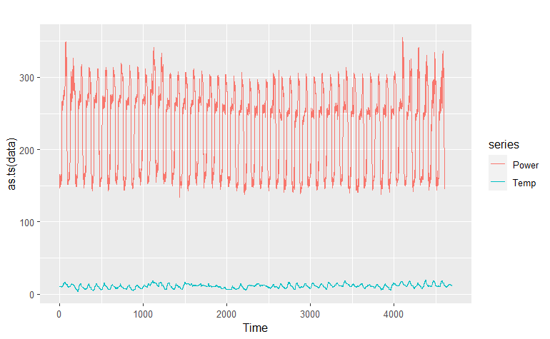

```r
autoplot(as.ts(data))
```

```r
# convert date column to date class
data$Timestamp <- as.POSIXlt(data$Timestamp, format = "%m/%d/%y  %H:%M")

# view R class of data
class(data$Timestamp)
```

```
[1] "POSIXlt" "POSIXt"
```

```r
## [1] "Date"

# view results
head(data$Timestamp)
```

```
[1] "2010-01-01 01:15:00 UTC" "2010-01-01 01:30:00 UTC" "2010-01-01 01:45:00 UTC" "2010-01-01 02:00:00 UTC"
[5] "2010-01-01 02:15:00 UTC" "2010-01-01 02:30:00 UTC"
```

```r
data_known <- ts(data[1:4603,], frequency = 96)
data_to_forecast <- ts(data[4604:4699,], frequency = 96)
#data_known_5 <- ts(data[1:4603,], frequency = 5)

#$Power <- ts(data$Power, frequency = 96)
#data$Temp <- ts(data$Temp, frequency = 96)
#Power <- data$Power
#Temp <- data$Temp'
```

```r
plot(data$Power,type='l',xlim=c(1,4603),ylim=c(120,360),xlab='Time',ylab='Power (kW)')
```

[output not shown]

```r
plot(data$Temp,type='l',xlim=c(1,4603),ylim=c(4,20),xlab='Time',ylab='Temperature (°C)')
```

[output not shown]

```r
autoplot(data)
```

Timestamp per day = 96 Nb total rows for Power = 4603 => 47 days + 91 timestamps Train => 80% => 3682.4 => floor(3682.4) => 3682 => 38 days + 34 timestamps Test => 20% => 920.6 => floor(920.6) => 921 => 9 days + 57 timestamps

```r
elec_train=window(data_known,start=c(1,1),end=c(39,35))
elec_test=window(data_known,start=c(39,36),end=c(48,91))
```

Other definition

```r
h2 <- 921L
#h2 <- 184L
elec_train2 <- head(data_known, round(length(data_known)/2 - h2))
elec_test2 <- tail(data_known, h2)
```

```r
elec_train <- elec_train2
elec_test <- elec_test2
```

```r
data_known_Power <- data_known[,1]
elec_train_Power <- elec_train[,1]
elec_test_Power <- elec_test[,1]
data_known_Temp <- data_known[,2]
elec_train_Temp <- elec_train[,2]
elec_test_Temp <- elec_test[,2]
elec_forcast_Temp <- data_to_forecast[,2]
summary(data_known_Power)
```

```
   Min. 1st Qu.  Median    Mean 3rd Qu.    Max.
  134.1   163.3   253.7   231.7   277.9   355.1
```

```r
summary(data_known_Temp)
```

```
   Min. 1st Qu.  Median    Mean 3rd Qu.    Max.
   3.90    8.90   11.10   10.89   12.80   19.40
```

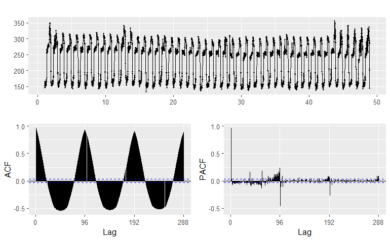

```r
ggtsdisplay(data_known_Power)
```

Seasonal pattern

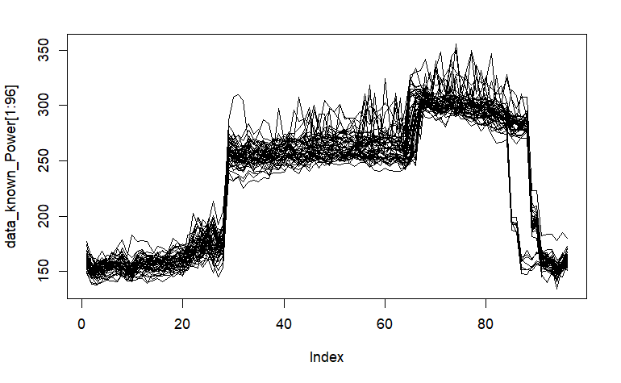

```r
plot(data_known_Power[1:96],type="l",ylim=c(min(data_known_Power),max(data_known_Power)))
for (i in 1:4603) lines(data_known_Power[(1+96*i):(96*(i+1))])
```

FORECASTING WITHOUT COVARIATES (Power)

1- Holt-Winters exponential smoothing

```r
fit1=hw(elec_train_Power,lambda="auto")
```

```
Error in ets(x, "AAA", alpha = alpha, beta = beta, gamma = gamma, phi = phi,  :
  Frequency too high
```

Frequency is too high to use Holt-Winters = Holt-Winters is really made for shorter seasonal periods.

2- SARIMA model

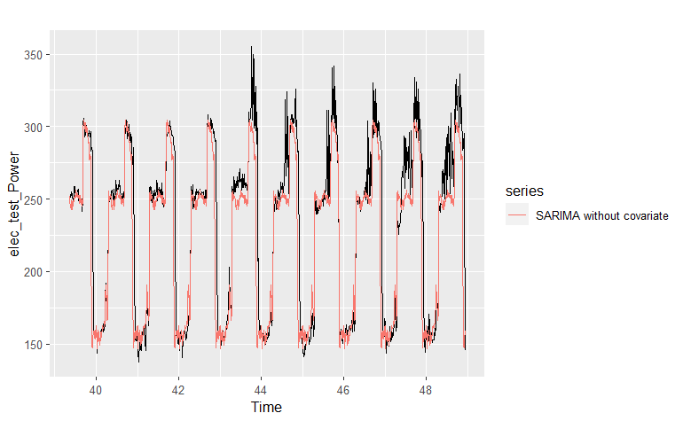

```r
fit2=auto.arima(elec_train_Power,lambda="auto")
prev2=forecast(fit2, h=921)
autoplot(elec_test_Power)+autolayer(prev2$mean,series="SARIMA without covariate")
```

RMSE :

```r
print(sqrt(mean((prev2$mean-elec_test_Power)^2)))
```

```
[1] 27.97736
```

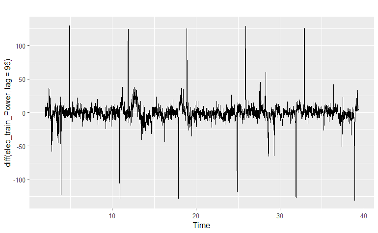

```r
autoplot(diff(elec_train_Power,lag = 96))
```

Forecasting with covariates

3 - Auto Arima

```r
elec_train_Temp_ts <- elec_train[,1] <- list(NULL)
elec_train_Temp_ts
```

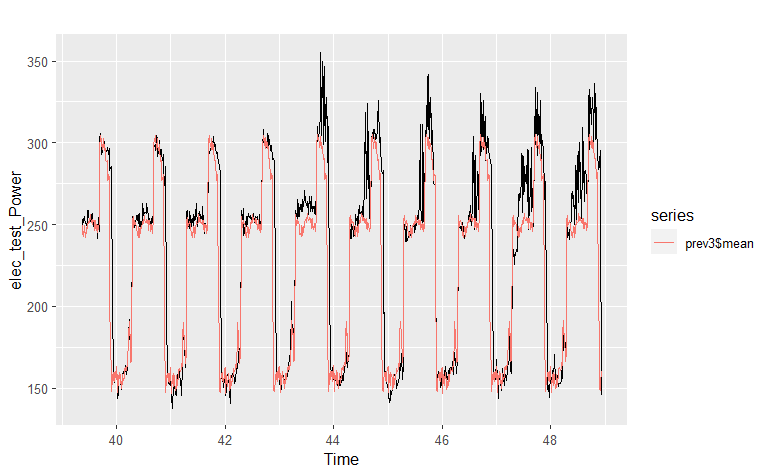

```r
fit3=auto.arima(elec_train[,"Power"],xreg=elec_train[,"Temp"])
prev3=forecast(fit3,h=921,xreg=elec_test_Temp)
autoplot(elec_test_Power)+autolayer(prev3$mean)
```

```r
print(sqrt(mean((prev3$mean-elec_test_Power)^2)))
```

```
[1] 27.72834
```

```r
summary(fit3)
```

```
Series: elec_train[, "Power"]
Regression with ARIMA(1,0,0)(0,1,0)[96] errors

Coefficients:
         ar1    xreg
      0.7705  0.2365
s.e.  0.0107  0.2433

sigma^2 = 99.04:  log likelihood = -13331.17
AIC=26668.35   AICc=26668.35   BIC=26686.9

Training set error measures:
                     ME     RMSE      MAE        MPE    MAPE      MASE        ACF1
Training set -0.1138152 9.818446 5.776375 -0.1347728 2.67172 0.7144459 -0.01628982
```

```
    Ljung-Box test

data:  Residuals from Regression with ARIMA(1,0,0)(0,1,0)[96] errors
Q* = 1349.6, df = 190, p-value < 2.2e-16

Model df: 2.   Total lags used: 192
```

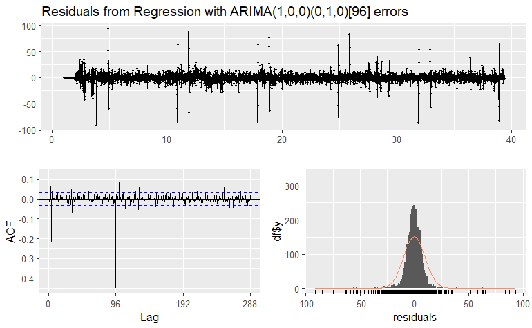

```r
checkresiduals(fit3)
```

P-value is very low and it seems that there is not really a relationship between Power and Temp :

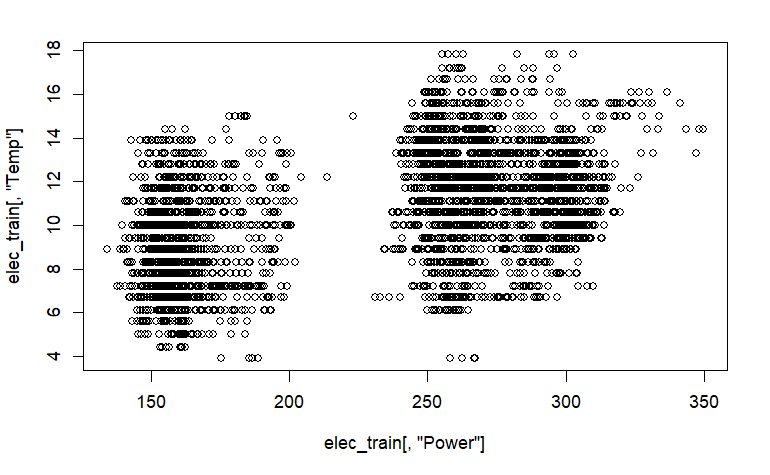

```r
plot(elec_train[,"Power"],elec_train[,"Temp"])
```

## Forecasting with a auto-regressive neural network

```r
fit4=nnetar(elec_train[,"Power"],T=96)
print(fit4)
```

```
Series: elec_train[, "Power"]
Model:  NNAR(20,1,11)[96]
Call:   nnetar(y = elec_train[, "Power"], T = 96)

Average of 20 networks, each of which is
a 21-11-1 network with 254 weights
options were - linear output units

sigma^2 estimated as 49.19
```

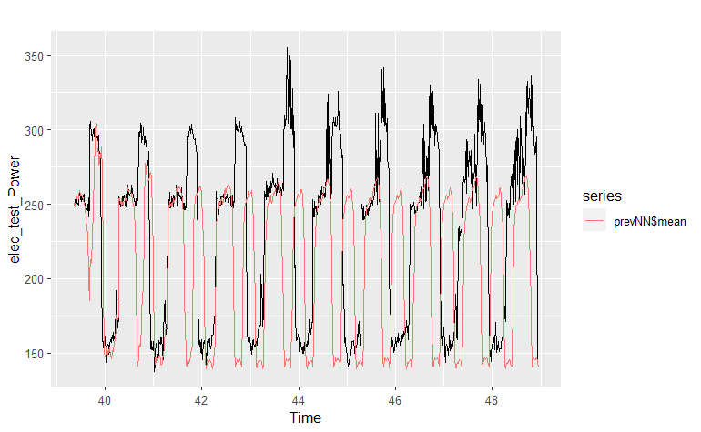

```r
prevNN=forecast(fit4,h=921)
autoplot(elec_test_Power)+autolayer(prevNN$mean)
```

RMSE :

```r
print(sqrt(mean((prevNN$mean-elec_test_Power)^2)))
```

```
[1] 77.37433
```

Manual improvements as the result proposed by the default settings are not suitable :

```r
fit5=nnetar(elec_train[,"Power"],p=8,P=10,T=96)
print(fit5)
```

```
Series: elec_train[, "Power"]
Model:  NNAR(8,10,10)[96]
Call:   nnetar(y = elec_train[, "Power"], p = 8, P = 10, T = 96)

Average of 20 networks, each of which is
a 18-10-1 network with 201 weights
options were - linear output units

sigma^2 estimated as 24.08
```

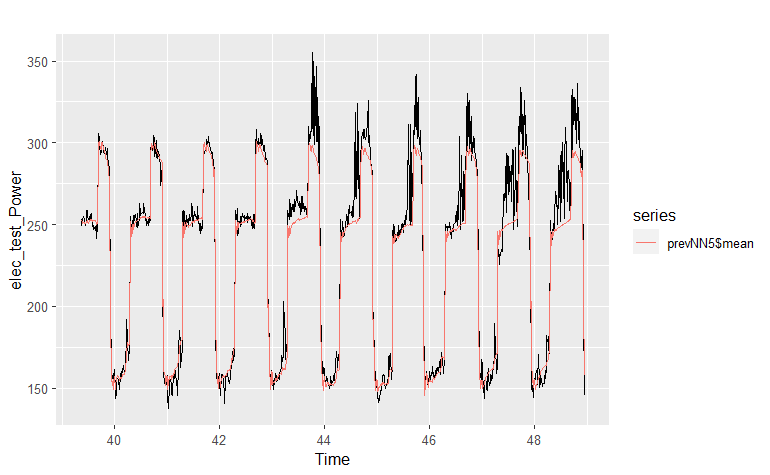

```r
prevNN5=forecast(fit5,h=921)
autoplot(elec_test_Power)+autolayer(prevNN5$mean)
```

RMSE :

```r
print(sqrt(mean((prevNN5$mean-elec_test_Power)^2)))
```

```
[1] 12.62383
```

Forecast based on Power only with NN

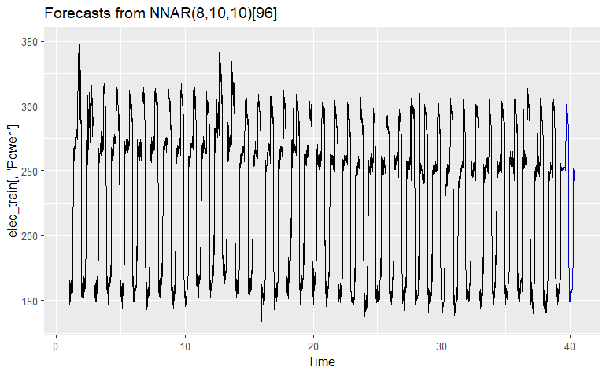

```r
autoplot(forecast(fit5,h=96))
```

## Forecasting with a auto-regressive neural network with covariates

```r
fit5=nnetar(elec_train[,"Power"], xreg=elec_train[,"Temp"],  T=96)
print(fit5)
```

```
Series: elec_train[, "Power"]
Model:  NNAR(20,1,12)[96]
Call:   nnetar(y = elec_train[, "Power"], xreg = elec_train[, "Temp"],
    T = 96)

Average of 20 networks, each of which is
a 22-12-1 network with 289 weights
options were - linear output units

sigma^2 estimated as 48.82
```

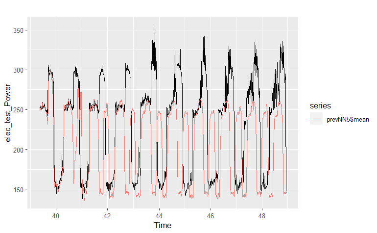

```r
prevNN5=forecast(fit5, xreg=elec_test[,"Temp"], h=921)
autoplot(elec_test_Power)+autolayer(prevNN5$mean)
```

RMSE :

```r
print(sqrt(mean((prevNN5$mean-elec_test_Power)^2)))
```

```
[1] 73.9055
```

Manual improvements as the result proposed by the default settings are not suitable :

```r
fit6=nnetar(elec_train[,"Power"], xreg=elec_train[,"Temp"],p=8,P=10,T=96)
print(fit6)
```

```
Series: elec_train[, "Power"]
Model:  NNAR(8,10,10)[96]
Call:   nnetar(y = elec_train[, "Power"], p = 8, P = 10, xreg = elec_train[,
    "Temp"], T = 96)

Average of 20 networks, each of which is
a 19-10-1 network with 211 weights
options were - linear output units

sigma^2 estimated as 23.84
```

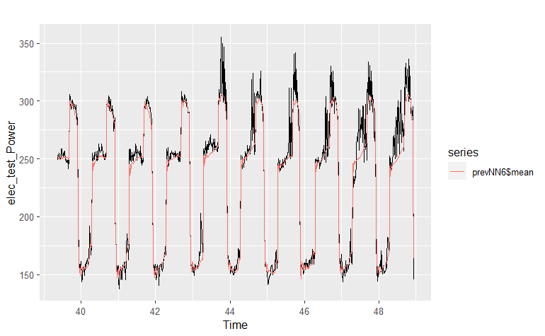

```r
prevNN6=forecast(fit6, xreg=elec_test[,"Temp"],h=921)
autoplot(elec_test_Power)+autolayer(prevNN6$mean)
```

RMSE :

```r
print(sqrt(mean((prevNN6$mean-elec_test_Power)^2)))
```

```
[1] 11.81847
```

Forecast based on Power and Temp with NN

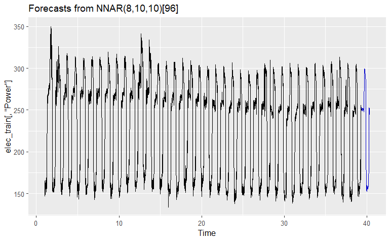

```r
forecast_NN_Cov <- forecast(fit6,xreg=elec_forcast_Temp,h=96)
autoplot(forecast_NN_Cov)
```